# R Notebook

# NOM PRENOM : DARGEL FLORIAN

Le but de ce TP est d’étudier les algorithmes d’arbres CART et Forêts aléatoires ainsi que l’importance et la sélection de variables avec les jeux de données de spam et d’ozone.

# 1] les données

On commence tout d’abord à charger la libraire kernlab et on se renseigne sur la base de données spam

```r
{library(kernlab) #librairie utile pour charger la database spam. Méthodes d'apprentissage automatique basées sur des noyaux pour la classification, la régression, le regroupement, la détection de la nouveauté, la régression quantile et la réduction de la dimensionnalité. Parmi d'autres méthodes, "kernlab" inclut les machines à vecteurs de support, le regroupement spectral, l'ACP à noyau, les processus gaussiens et un solveur QP.

?data(spam)
}
```

[output not shown]

La variable cible est le spam, il serait intéressant d’observer la répartion des spams et non spams

```
 On a 60.59552 % de notre distribution qui sont des non spam
 On a 39.40448 % de notre distribution qui sont des spam
```

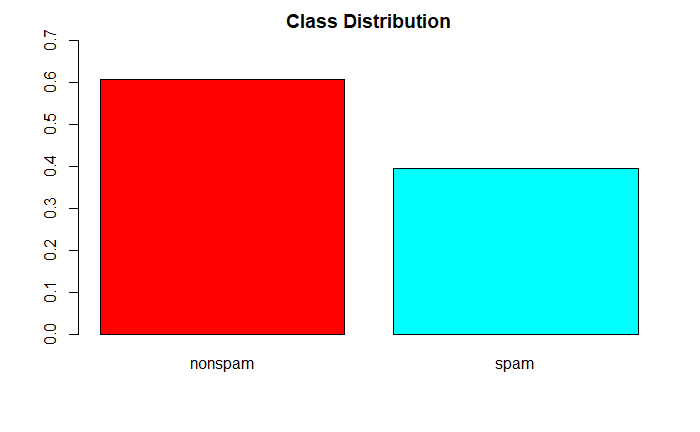

```r
{
barplot(prop.table(table(spam$type)),
        col = rainbow(2),
        ylim = c(0, 0.7),
        main = "Class Distribution")

cat("\n On a", table(spam$type)[1]/ (table(spam$type)[1] + table(spam$type)[2]) * 100, "% de notre distribution qui sont des non spam")
cat("\n On a",table(spam$type)[2]/ (table(spam$type)[1] + table(spam$type)[2]) * 100, "% de notre distribution qui sont des spam")
}
```

```
- Un indicateur trivial qui pourrait nous servir de référence à un taux d'erreur de 39.40448 % (environ 39% de chance que se soit un spam).
```

Je prépare par la suite une base d’apprentissage et une base de test.

```r
set.seed(9146301)
ytable <- table(spam$type)
app <- c(sample(1:ytable[2], ytable[2]/2), sample((ytable[2] + 1):nrow(spam),
ytable[1]/2))
spam.app <- spam[app, ]
table(spam.app$type)
```

```
nonspam    spam
   1394     906
```

```r
n <- nrow(spam.app)
p <- ncol(spam.app) - 1
spam.test <- spam[-app, ]
table(spam.test$type)
```

```
nonspam    spam
   1394     907
```

```r
{
cat("\n On a", (table(spam.app$type)[1] +  table(spam.app$type)[2]) / 4601 * 100, "% de données pour l'entrainement" )
cat("\n On a un ratio de",table(spam.app$type)[1]/ table(spam.app$type)[2], "pour l'entrainement")

cat("\n \n On a", (table(spam.test$type)[1] +  table(spam.test$type)[2]) / 4601 * 100, "% de données pour le test" )
cat("\n On a un ratio de", table(spam.test$type)[1]/ table(spam.test$type)[2], "pour le test")
}
```

```
 On a 49.98913 % de données pour l'entrainement
 On a un ratio de 1.538631 pour l'entrainement

 On a 50.01087 % de données pour le test
 On a un ratio de 1.536935 pour le test
```

le ratio de spam est conservé. La répartition sur le nombre de spam et non-spam répartis dans la base d’entrainement et de test sont quasiment similaires.

# 2] Arbre cart

## 2.1] Arbre par défaut

On charge la librairie rpart. Le package R rpart propose une implémentation des méthodes de construction d’arbres de décision inspirées de l’approche CART décrite dans l’ouvrage éponyme de Breiman, Friedman, Olshen et Stone en 1983.

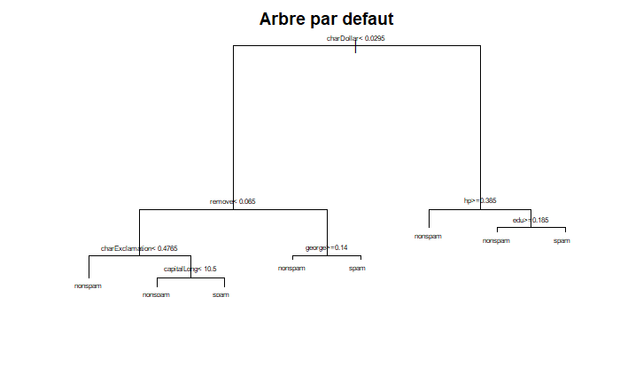

```r
library(rpart)

t_def=rpart(type ~ .,data = spam.app) #construction de l'arbre avec les paramètres par défaut fournit par rpart
plot(t_def, main="Arbre par defaut")
text(t_def, cex = 0.5)
```

[output not shown]

Maintenant que nous avons généré un arbre avec les paramètres par défaut, On peut identifier ces paramètres et les analyser. La fonction summary() permet d’avoir le détail de la construction de l’arbre.

```r
summary(t_def)
```

```
Call:
rpart(formula = type ~ ., data = spam.app)
  n= 2300

          CP nsplit rel error    xerror       xstd
1 0.48454746      0 1.0000000 1.0000000 0.02586446
2 0.13686534      1 0.5154525 0.5264901 0.02146152
3 0.06512141      2 0.3785872 0.3830022 0.01894627
4 0.04746137      3 0.3134658 0.3211921 0.01759723
5 0.02649007      4 0.2660044 0.2792494 0.01656254
6 0.01324503      5 0.2395143 0.2538631 0.01588024
7 0.01103753      6 0.2262693 0.2494481 0.01575674
8 0.01000000      7 0.2152318 0.2417219 0.01553696

Variable importance
     charDollar          remove          num000           money charExclamation     capitalLong              hp        internet
             25              11              10               9               7               7               6               5
         credit             hpl          george             edu    capitalTotal      capitalAve            labs            free
              5               3               2               1               1               1               1               1
         telnet           num85             lab
              1               1               1

Node number 1: 2300 observations,    complexity param=0.4845475
  predicted class=nonspam  expected loss=0.393913  P(node) =1
    class counts:  1394   906
   probabilities: 0.606 0.394
  left son=2 (1683 obs) right son=3 (617 obs)
  Primary splits:
      charDollar      < 0.0295 to the left,  improve=359.7022, (0 missing)
      charExclamation < 0.0825 to the left,  improve=327.4305, (0 missing)
      remove          < 0.01   to the left,  improve=299.7582, (0 missing)
      free            < 0.095  to the left,  improve=276.1917, (0 missing)
      your            < 0.415  to the left,  improve=265.4747, (0 missing)
  Surrogate splits:
      num000      < 0.015  to the left,  agree=0.831, adj=0.371, (0 split)
      money       < 0.045  to the left,  agree=0.824, adj=0.345, (0 split)
      internet    < 0.035  to the left,  agree=0.786, adj=0.201, (0 split)
      capitalLong < 52.5   to the left,  agree=0.786, adj=0.201, (0 split)
      credit      < 0.035  to the left,  agree=0.781, adj=0.183, (0 split)

```

[output cut: 128 more lines]

```

Node number 15: 546 observations
  predicted class=spam     expected loss=0.04761905  P(node) =0.2373913
    class counts:    26   520
   probabilities: 0.048 0.952

Node number 18: 66 observations
  predicted class=nonspam  expected loss=0.3181818  P(node) =0.02869565
    class counts:    45    21
   probabilities: 0.682 0.318

Node number 19: 103 observations
  predicted class=spam     expected loss=0.09708738  P(node) =0.04478261
    class counts:    10    93
   probabilities: 0.097 0.903
```

**Interpretation du summary**

```
Par exemple lors du 1er split
left son=2 (1683 obs) right son=3 (617 obs): "fils" nous indique le numéro du nœud suivant en dessous de cette division. Les nombres      "obs" correspondent au nombre de données d'entraînement de chaque côté. (1683 vers le fils 2 et 617 vers le fils 3)

Pour le split compétitif (primary split)  : En tête de liste, la variable qui réalise le gain maximum (variable active de l’arbre) est     charDollar.
les 4 autres variables concurrentes sont : charExclamation, remove, free, your.

Pour les splits de substitution (Surrogate splits) , en tête de liste de la partie surrogate, la variable ayant la concordance la plus     forte avec la variable active du noeud est num000.
Les 4 autres variables surrogate (par ordre de concordance avec la variable active) sont, money, internet, capitalLong et credit.
```

La fonction summary()nous donne des informations complets. On peut sélectionner uniquement les informations qui nous intéresse. Par exemple, il est important de regarder l’importance de chaque variable (hiérarchisation).

```r
t_def$variable.importance
```

```
     charDollar          remove          num000           money charExclamation     capitalLong              hp        internet
    359.7022076     155.6751747     140.1593204     131.3735775     102.2539680     101.7926359      79.3749598      72.2902330
         credit             hpl          george             edu    capitalTotal      capitalAve            labs            free
     66.8753075      38.4816665      28.2282760      21.2822403      21.2550748      19.5880101      15.9136995      11.0517247
         telnet           num85             lab          num415          num857            your             you           num3d
     11.0171766       8.6055497       8.5689151       6.8844398       6.8844398       5.4179602       5.0011941       1.9958356
             cs        business             all          people
      1.3301400       0.9979178       0.6050531       0.6050531
```

On remarque les variables importantes qui apparaissent sont charDollar (un mail où l’argent apparait a plus de chance d’être un spam que un non spam). Les deux variables suivantes qui sont les plus importantes sont remove et num000.

## 2.2] Arbre de profondeur 1

On construit cette fois ci un arbre avec une profondeur de 1.

```
n= 2300

node), split, n, loss, yval, (yprob)
      * denotes terminal node

1) root 2300 906 nonspam (0.6060870 0.3939130)
  2) charDollar< 0.0295 1683 378 nonspam (0.7754011 0.2245989) *
  3) charDollar>=0.0295 617  89 spam (0.1442464 0.8557536) *
```

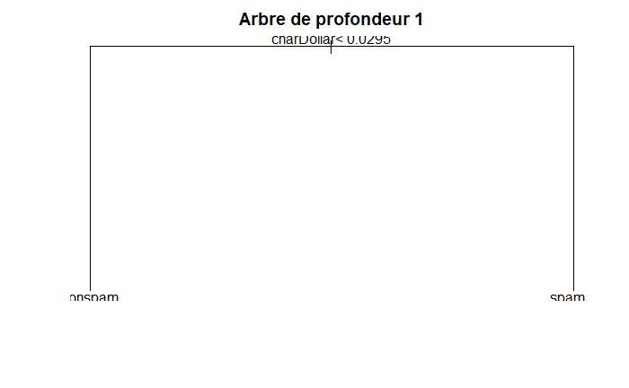

```r
{
tstump <- rpart(type ~ ., spam.app, control = rpart.control(maxdepth = 1))
plot(tstump, main='Arbre de profondeur 1')
text(tstump)

tstump
}
```

```r
summary(tstump)
```

```
Call:
rpart(formula = type ~ ., data = spam.app, control = rpart.control(maxdepth = 1))
  n= 2300

         CP nsplit rel error    xerror       xstd
1 0.4845475      0 1.0000000 1.0000000 0.02586446
2 0.0100000      1 0.5154525 0.5242826 0.02142822

Variable importance
 charDollar      num000       money capitalLong    internet      credit
         43          16          15           9           9           8

Node number 1: 2300 observations,    complexity param=0.4845475
  predicted class=nonspam  expected loss=0.393913  P(node) =1
    class counts:  1394   906
   probabilities: 0.606 0.394
  left son=2 (1683 obs) right son=3 (617 obs)
  Primary splits:
      charDollar      < 0.0295 to the left,  improve=359.7022, (0 missing)
      charExclamation < 0.0825 to the left,  improve=327.4305, (0 missing)
      remove          < 0.01   to the left,  improve=299.7582, (0 missing)
      free            < 0.095  to the left,  improve=276.1917, (0 missing)
      your            < 0.415  to the left,  improve=265.4747, (0 missing)
  Surrogate splits:
      num000      < 0.015  to the left,  agree=0.831, adj=0.371, (0 split)
      money       < 0.045  to the left,  agree=0.824, adj=0.345, (0 split)
      internet    < 0.035  to the left,  agree=0.786, adj=0.201, (0 split)
      capitalLong < 52.5   to the left,  agree=0.786, adj=0.201, (0 split)
      credit      < 0.035  to the left,  agree=0.781, adj=0.183, (0 split)

Node number 2: 1683 observations
  predicted class=nonspam  expected loss=0.2245989  P(node) =0.7317391
    class counts:  1305   378
   probabilities: 0.775 0.225

Node number 3: 617 observations
  predicted class=spam     expected loss=0.1442464  P(node) =0.2682609
    class counts:    89   528
   probabilities: 0.144 0.856
```

En observant le split du noeud interne, pour le split compétitif et le split de subsitution, on se rend compte que se sont les mêmes variables qui sont apparus dans le même ordre que l’arbre par défaut lors du 1er split.

Pour le split compétitif : En tête de liste, la variable qui réalise le gain maximum (variable active de l’arbre) est charDollar. Suivi de charExclamation, remove, free, your.

Pour les splits de substitution, en tête de liste de la partie surrogate, la variable ayant la concordance la plus forte avec la variable active du noeud est num000. Suivi de money, internet, capitalLong et credit.

## 2.3] Explication split compétitif et split de substitution

En classification, on cherche à diminuer la fonction de pureté de Gini, et donc à augmenter l’homogénéité des nœuds obtenus.

Le split competitifs, nous donne la variable qui à la valeur de l’indice de Gini le plus élevé. Spliter avec la première variable qui est donnée par split competitifs nous permet de réduire de manière importante l’hétérégénéité.

Cette première variable fait office ici de la variable qui réduit le plus l’hétérogénéité lors du split.

## 2.4] Construction d’un arbre maximal

On construit l’arbre maximal Tmax qui est un arbre pleinement développé grâce à la commande minsplit et cp.

la commande minsplit permet d’indiquer le nombre minimum d’individus présents à l’étape d’un nœud pour envisager une coupure.

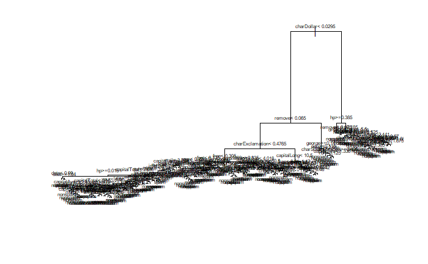

```r
{tmax <- rpart(type ~ ., data = spam.app, control = rpart.control(minsplit = 1,
cp = 0))
plot(tmax)
text(tmax, cex = 0.5)
}
```

```
L’arbre maximal a tendance à possèder une très grande variance et un biais faible. En visualisant sur le graphique, on constate qu'il peut être difficilement interprétable lorsqu'on a un grand nombre de feuille.

On peut améliorer légerement la visualisation avec la librairie library(rpart.plot) (ci-dessous).
```

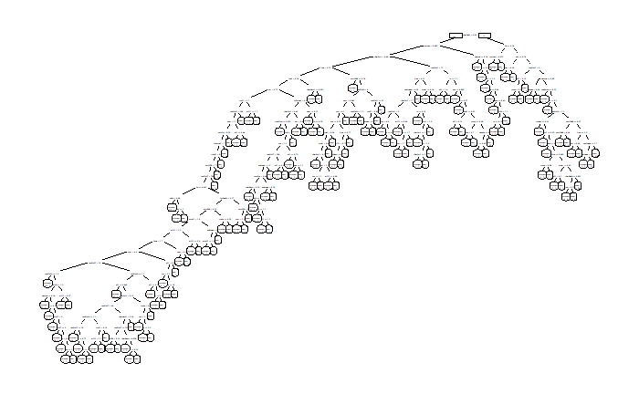

```r
{
library(rpart.plot)
prp(tmax,extra=1)
}
```

On va maintenant dessiner les erreurs de validation croisée de la suite de Breiman des sous-arbres élagués de l’arbre maximal.

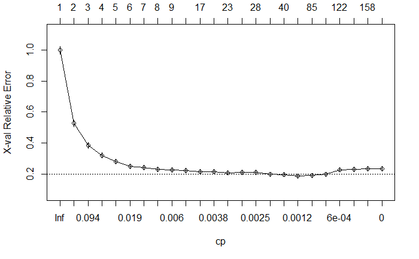

```r
plotcp(tmax)
```

[output not shown]

*Interprétation :*

```
On constate qu'en analysant le cp (paramètre de complexité, ou encore critère de pénalité),  les performances s'améliorent dans un         premier temps quand on augmente le nombre de feuilles puis se dégradent en raison du sur-apprentissage.

l’erreur moyenne par validation croisée diminue jusqu'à une certaine valeur cp (visuellement sur le graphique: 0.0012 environ) puis augmente. Visuellement on peut dire que l'arbre minimisant le critère posséde entre 40 et 85 feuilles.
```

On choisit en général la complexité qui minimise l’erreur estimée. On peut observer les résultats sur le tableau ci-dessous.

```r
printcp(tmax)
```

```
Classification tree:
rpart(formula = type ~ ., data = spam.app, control = rpart.control(minsplit = 1,
    cp = 0))

Variables actually used in tree construction:
 [1] address           all               business          capitalAve        capitalLong       capitalTotal      charDollar
 [8] charExclamation   charHash          charRoundbracket  charSemicolon     charSquarebracket conference        credit
[15] data              edu               email             font              free              george            hp
[22] hpl               internet          labs              mail              make              meeting           money
[29] num000            num1999           num3d             num650            order             original          our
[36] over              people            re                receive           remove            technology        will
[43] you               your

Root node error: 906/2300 = 0.39391

```

[output cut: 27 more lines]

```
C’est à partir de la table cp que nous allons déterminer notre arbre optimal. C’est à dire celui qui minimise l’erreur xerror obtenu par validation croisée.
On se base sur la colonne xerror, dans notre cas la valeur minimal est : 0.18543  (ligne 18 du tableau) donc le cp optimal est 0.00110375. Après avoir distingué visuelement sur la table cp, on peut vérifier et obtenir cette valeur avec la commande ci-dessous.
```

```r
tmax$cptable[which.min(tmax$cptable[, 4]), 1]
```

```
[1] 0.001103753
```

Cette étape de l’algorithme CART, s’appelle l’élagage et consiste à chercher le meilleur sous-arbre élagué de l’arbre maximal (meilleur au sens de l’erreur de généralisation). On va utiliser la commande “prune”.

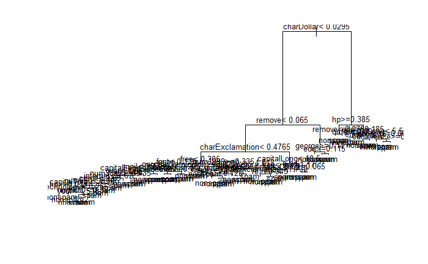

```r
tprune <- prune(tmax, cp = tmax$cptable[which.min(tmax$cptable[, 4]), 1])
plot(tprune)
text(tprune, cex = 0.8)
```

```
On a le meilleur sous arbre élagué de l’arbre maximal, l'arbre reste toujours difficile à interpreté car il a une profondeur assez elevée.
```

## 2.5] Regle du 1-se

On applique la règle de l’écart type (“1-SE”) pour choisir un cp inférieur mais aussi l’arbre le plus petit.

```r
# regle 1-se
#min(tmax$cptable[, "xerror"]) + (1*tmax$cptable[ which.min(tmax$cptable[, "xerror"]), "xstd"])
```

```r
#commande equivalent à la précédente
#sum(tmax$cptable[ which.min(tmax$cptable[, 4]), 4:5])
```

```r
# 1-se
se = min(tmax$cptable[, "xerror"]) + (1*tmax$cptable[ which.min(tmax$cptable[, "xerror"]), "xstd"])
tmax$cptable
```

```
             CP nsplit   rel error    xerror       xstd
1  0.4845474614      0 1.000000000 1.0000000 0.02586446
2  0.1368653422      1 0.515452539 0.5264901 0.02146152
3  0.0651214128      2 0.378587196 0.3852097 0.01899106
4  0.0474613687      3 0.313465784 0.3200883 0.01757134
5  0.0264900662      4 0.266004415 0.2803532 0.01659119
6  0.0132450331      5 0.239514349 0.2494481 0.01575674
7  0.0110375276      6 0.226269316 0.2417219 0.01553696
8  0.0066225166      7 0.215231788 0.2295806 0.01518170
9  0.0055187638      8 0.208609272 0.2262693 0.01508262
10 0.0048565121      9 0.203090508 0.2229581 0.01498257
11 0.0044150110     16 0.165562914 0.2141280 0.01471086
12 0.0033112583     19 0.152317881 0.2152318 0.01474522
13 0.0029433407     22 0.142384106 0.2075055 0.01450220
14 0.0027593819     25 0.133554084 0.2097130 0.01457223
15 0.0022075055     27 0.128035320 0.2097130 0.01457223
16 0.0016556291     33 0.114790287 0.1964680 0.01414460
17 0.0012417219     39 0.104856512 0.1953642 0.01410813
18 0.0011037528     48 0.092715232 0.1854305 0.01377387
19 0.0008278146     84 0.051876380 0.1898455 0.01392380
20 0.0006622517     88 0.048565121 0.1964680 0.01414460
21 0.0005518764    121 0.025386313 0.2273731 0.01511575
22 0.0003679176    151 0.008830022 0.2295806 0.01518170
23 0.0001839588    157 0.006622517 0.2328918 0.01527982
24 0.0000000000    163 0.005518764 0.2328918 0.01527982
```

```r
#la valeur du 1-se
se
```

```
[1] 0.1992043
```

```r
#selection du plus petit arbre
tmax$cptable[tmax$cptable[,"xerror"]<se , "xerror"]
```

```
       16        17        18        19        20
0.1964680 0.1953642 0.1854305 0.1898455 0.1964680
```

L’arbre minimal avec l’erreur la plus petite est atteint avec un cp de 0.001655629 (ligne 16 de la table cp) et avec une taille de 33 noeuds. .*

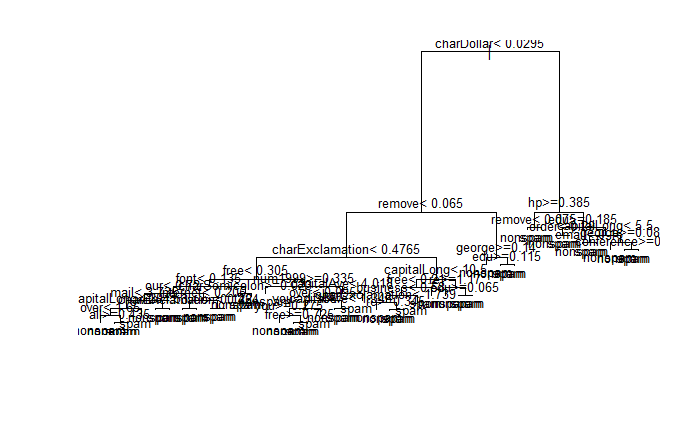

```r
tprune_1sd  = prune(tmax, cp=0.001655629)

plot(tprune_1sd)
text(tprune_1sd, cex = 0.8)
```

## 2.6] Comparaison des arbres

Le meilleur sous-arbre élagué de l’arbre maximal (à un écart-type près) comporte plus de feuilles, de noeuds et de variable que l’arbre par défaut.

```r
identical(t_def, tprune_1sd)
```

```
[1] FALSE
```

```r
identical(tprune, tprune_1sd)
```

```
[1] FALSE
```

```
On observe que nos arbres ne sont pas identiques :
- Pour l'arbre par defaut et prune
- Pour l'arbre prune et prune 1_sd

Le meilleur sous-arbre élagué de l’arbre maximal (à un écart-type près) comporte plus de feuilles, de noeuds et de variable que l'arbre par défaut

Les arbres prune et tprune_1sd ne sont pas identiques, en effet car ils n'ont pas le même nombre de feuille. Le meilleur sous-arbre élagué de l’arbre maximal à un écart-type près (tprune_1sd) a moins de feuille que le tprune.
```

```r
{
predstump <- predict(tstump, spam.test, type="class")
errstump <- round(sum(predstump!=spam.test$type)/nrow(spam.test), 3) *100
appstump <- round(sum(predict(tstump, spam.app, type="class")!=spam.app$type)/nrow(spam.app), 3) * 100
cat("Pour une seule profondeur \n")
cat("erreur d'apprentissage est de", appstump, "%" )
cat("\n erreur de test est de", errstump, "%" )

predmax <- predict(tmax, spam.test, type="class")
errmax <- round(sum(predmax!=spam.test$type)/nrow(spam.test), 3) * 100
appmax <- round(sum(predict(tmax, spam.app, type="class")!=spam.app$type)/nrow(spam.app), 3) * 100
cat("\n \n Pour l'arbre maximal \n")
cat("L'erreur d'apprentissage est de", appmax, "%")
cat("\n L'erreur de test est de", errmax, "%")

predprune <- predict(tprune, spam.test, type="class")
errprune <- round(sum(predprune!=spam.test$type)/nrow(spam.test), 3) *100
appprune <- round(sum(predict(tprune, spam.app, type="class")!=spam.app$type)/nrow(spam.app), 3) * 100
cat("\n \n Pour l'arbre prune \n")
cat("L'erreur d'apprentissage est de", appprune, "%")
cat("\n L'erreur de test est de", errprune, "%")


preddef<- predict(t_def, spam.test, type="class")
errtdef <- round(sum(preddef!=spam.test$type)/nrow(spam.test), 3) * 100
apptdef <- round(sum(predict(t_def, spam.app, type="class")!=spam.app$type)/nrow(spam.app), 3) * 100
cat("\n \n Pour l'arbre par defaut \n ")
cat("L'erreur d'apprentissage est de", apptdef, "%")
cat("\n L'erreur de test est de", errtdef, "%")




predprune_1sd<- predict(tprune_1sd, spam.test, type="class")
errtprune_1sd <- round(sum(predprune_1sd!=spam.test$type)/nrow(spam.test), 3) * 100
apptprune_1sd <- round(sum(predict(tprune_1sd, spam.app, type="class")!=spam.app$type)/nrow(spam.app), 3) * 100
cat("\n \n  la règle du 1 SE \n ")
cat("L'erreur d'apprentissage est de", apptprune_1sd, "%")
cat("\n L'erreur de test est de", errtprune_1sd, "%")
}
```

```
Pour une seule profondeur
erreur d'apprentissage est de 20.3 %
 erreur de test est de 21 %

 Pour l'arbre maximal
L'erreur d'apprentissage est de 0.2 %
 L'erreur de test est de 9 %

 Pour l'arbre prune
L'erreur d'apprentissage est de 3.7 %
 L'erreur de test est de 8.9 %

 Pour l'arbre par defaut
 L'erreur d'apprentissage est de 8.5 %
 L'erreur de test est de 10.1 %

  la règle du 1 SE
 L'erreur d'apprentissage est de 4.1 %
 L'erreur de test est de 9.3 %
```

On remarque que l’arbre maximal (trop complexe) a une erreur empirique (i.e. sur l’échantillon d’apprentissage) quasiment nulle et que l’arbre à une profondeur (trop simple) présente des erreurs test et empirique elevé et proches. L’arbre optimal prune, quant à lui, a la meilleure erreur test qui est de 8,9%.

# 3] OZONE

## 3.1]Description du dataset et nettoyage de données

```r
library(mlbench)
data(Ozone)
?Ozone
```

```
Description : Le jeux de données est "Los Angeles ozone pollution data, 1976". Il s'agit d'une base de données avec 366 observations sur 13 variables, chaque observation correspond à un jour. Le but s'agit de prédire la valeur maximale quotidienne de la moyenne horaire de l'ozone.

Format :Month: 1 = January, ..., 12 = December
        2 Jour du mois
        3 Day of week: 1 = Monday, ..., 7 = Sunday
        4 Daily maximum one-hour-average ozone reading
        5 500 millibar pressure height (m) measured at Vandenberg AFB
        6 Wind speed (mph) at Los Angeles International Airport (LAX)
        7 Humidity (%) at LAX
        8 Temperature (degrees F) measured at Sandburg, CA
        9 Temperature (degrees F) measured at El Monte, CA
        10Inversion base height (feet) at LAX
        11Pressure gradient (mm Hg) from LAX to Daggett, CA
        12Inversion base temperature (degrees F) at LAX
        13Visibility (miles) measured at LAX

Source : Leo Breiman, Department of Statistics, UC Berkeley. Data used in Leo Breiman and Jerome H. Friedman (1985), Estimating optimal transformations for multiple regression and correlation, JASA, 80, pp. 580-598.
```

```r
str(Ozone)
```

```
'data.frame':   366 obs. of  13 variables:
 $ V1 : Factor w/ 12 levels "1","2","3","4",..: 1 1 1 1 1 1 1 1 1 1 ...
 $ V2 : Factor w/ 31 levels "1","2","3","4",..: 1 2 3 4 5 6 7 8 9 10 ...
 $ V3 : Factor w/ 7 levels "1","2","3","4",..: 4 5 6 7 1 2 3 4 5 6 ...
 $ V4 : num  3 3 3 5 5 6 4 4 6 7 ...
 $ V5 : num  5480 5660 5710 5700 5760 5720 5790 5790 5700 5700 ...
 $ V6 : num  8 6 4 3 3 4 6 3 3 3 ...
 $ V7 : num  20 NA 28 37 51 69 19 25 73 59 ...
 $ V8 : num  NA 38 40 45 54 35 45 55 41 44 ...
 $ V9 : num  NA NA NA NA 45.3 ...
 $ V10: num  5000 NA 2693 590 1450 ...
 $ V11: num  -15 -14 -25 -24 25 15 -33 -28 23 -2 ...
 $ V12: num  30.6 NA 47.7 55 57 ...
 $ V13: num  200 300 250 100 60 60 100 250 120 120 ...
```

Dans notre base de données on observe qu’on a 10 variables numériques et 3 variables non numérique (V1,V2,V3). Le fait qu’on ait des variables numériques et non numériques ne posera pas problème du fait que les arbres prennent en compte les modalités.

Il est important de connaitre le pourcentage de valeur manquante pour chaque variable,

```
 Variables sorted by number of missings:
```

| Variable | Count |
| --- | --- |
| V9 | 0.379781421 |
| V7 | 0.040983607 |
| V10 | 0.040983607 |
| V12 | 0.038251366 |
| V5 | 0.032786885 |
| V4 | 0.013661202 |
| V8 | 0.005464481 |
| V11 | 0.002732240 |
| V1 | 0.000000000 |
| V2 | 0.000000000 |

[output cut: 3 more lines]

| variable | q_zeros | p_zeros | q_na | p_na | q_inf | p_inf | type | unique |
| --- | --- | --- | --- | --- | --- | --- | --- | --- |
| V1 | 0 | 0.00 | 0 | 0.00 | 0 | 0 | factor | 12 |
| V2 | 0 | 0.00 | 0 | 0.00 | 0 | 0 | factor | 31 |
| V3 | 0 | 0.00 | 0 | 0.00 | 0 | 0 | factor | 7 |
| V4 | 0 | 0.00 | 5 | 1.37 | 0 | 0 | numeric | 35 |
| V5 | 0 | 0.00 | 12 | 3.28 | 0 | 0 | numeric | 53 |
| V6 | 18 | 4.92 | 0 | 0.00 | 0 | 0 | numeric | 11 |
| V7 | 0 | 0.00 | 15 | 4.10 | 0 | 0 | numeric | 67 |
| V8 | 0 | 0.00 | 2 | 0.55 | 0 | 0 | numeric | 64 |
| V9 | 0 | 0.00 | 139 | 37.98 | 0 | 0 | numeric | 147 |
| V10 | 0 | 0.00 | 15 | 4.10 | 0 | 0 | numeric | 208 |

[output cut: 3 more lines]

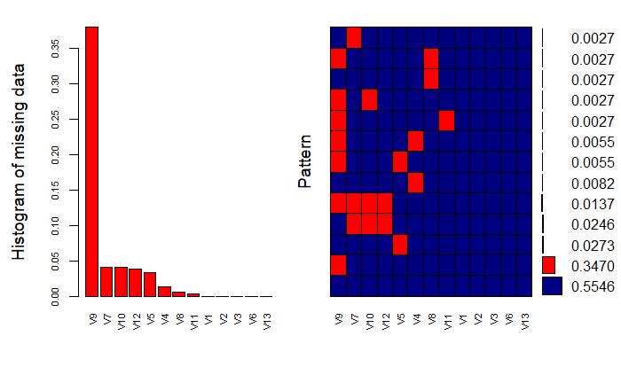

```r
{
library(VIM)
aggr_plot <- aggr(Ozone, col=c('navyblue','red'), numbers=TRUE, sortVars=TRUE, labels=names(Ozone), cex.axis=.7, gap=3, ylab=c("Histogram of missing data","Pattern"))

library(funModeling)
df_status(Ozone)

}
```

[output not shown]

La variable V8 et V9 sont tous les deux des températures, il serait intéressant d’observer la relation linéaire entre ses deux variables.

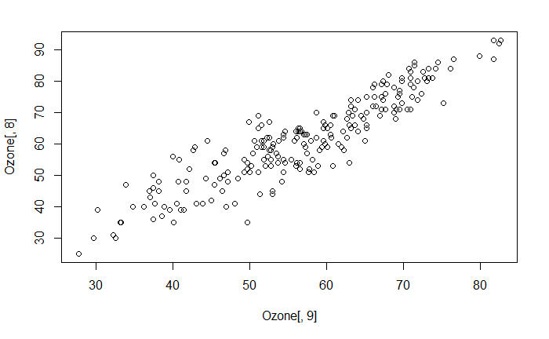

```r
#relation linéaire entre la variable V9 et V8
plot(Ozone[,9], Ozone[,8])
```

Visuellement, on peut observer qu’il y a une corrélation linéaire positive assez importante entre la variable V9 et V8, on peut donc supprimer la variable V9 et garder la variable V8.

```r
Ozone[,2]
```

```
  [1] 1  2  3  4  5  6  7  8  9  10 11 12 13 14 15 16 17 18 19 20 21 22 23 24 25 26 27 28 29 30 31 1  2  3  4  5  6  7  8  9  10 11
 [43] 12 13 14 15 16 17 18 19 20 21 22 23 24 25 26 27 28 29 1  2  3  4  5  6  7  8  9  10 11 12 13 14 15 16 17 18 19 20 21 22 23 24
 [85] 25 26 27 28 29 30 31 1  2  3  4  5  6  7  8  9  10 11 12 13 14 15 16 17 18 19 20 21 22 23 24 25 26 27 28 29 30 1  2  3  4  5
[127] 6  7  8  9  10 11 12 13 14 15 16 17 18 19 20 21 22 23 24 25 26 27 28 29 30 31 1  2  3  4  5  6  7  8  9  10 11 12 13 14 15 16
[169] 17 18 19 20 21 22 23 24 25 26 27 28 29 30 1  2  3  4  5  6  7  8  9  10 11 12 13 14 15 16 17 18 19 20 21 22 23 24 25 26 27 28
[211] 29 30 31 1  2  3  4  5  6  7  8  9  10 11 12 13 14 15 16 17 18 19 20 21 22 23 24 25 26 27 28 29 30 31 1  2  3  4  5  6  7  8
[253] 9  10 11 12 13 14 15 16 17 18 19 20 21 22 23 24 25 26 27 28 29 30 1  2  3  4  5  6  7  8  9  10 11 12 13 14 15 16 17 18 19 20
[295] 21 22 23 24 25 26 27 28 29 30 31 1  2  3  4  5  6  7  8  9  10 11 12 13 14 15 16 17 18 19 20 21 22 23 24 25 26 27 28 29 30 1
[337] 2  3  4  5  6  7  8  9  10 11 12 13 14 15 16 17 18 19 20 21 22 23 24 25 26 27 28 29 30 31
Levels: 1 2 3 4 5 6 7 8 9 10 11 12 13 14 15 16 17 18 19 20 21 22 23 24 25 26 27 28 29 30 31
```

La variable V2 Day of month (nombre de jours dans le mois). Il s’agit d’une données contenant une grande quantité d’informations supplémentaires sans signification à notre problème. Les données bruyantes peuvent affecter négativement les résultats de toute analyse de données et fausser les conclusions si elles ne sont pas gérées correctement.On va donc supprimer cette variable.

```r
#Suppression de la variable V9 et V2
Ozone<-Ozone[,-9]
Ozone<-Ozone[,-2]
head(Ozone)
```

|  | V1 | V3 | V4 | V5 | V6 | V7 | V8 | V10 | V11 | V12 | V13 |
| --- | --- | --- | --- | --- | --- | --- | --- | --- | --- | --- | --- |
| 1 | 1 | 4 | 3 | 5480 | 8 | 20 | NA | 5000 | -15 | 30.56 | 200 |
| 2 | 1 | 5 | 3 | 5660 | 6 | NA | 38 | NA | -14 | NA | 300 |
| 3 | 1 | 6 | 3 | 5710 | 4 | 28 | 40 | 2693 | -25 | 47.66 | 250 |
| 4 | 1 | 7 | 5 | 5700 | 3 | 37 | 45 | 590 | -24 | 55.04 | 100 |
| 5 | 1 | 1 | 5 | 5760 | 3 | 51 | 54 | 1450 | 25 | 57.02 | 60 |
| 6 | 1 | 2 | 6 | 5720 | 4 | 69 | 35 | 1568 | 15 | 53.78 | 60 |

## 3.2] Imputation valeur manquante

```r
Ozone$V4
```

```
  [1]  3  3  3  5  5  6  4  4  6  7  4  6  5  4  4  7  5  9  4  3  4  4  5  6  9  5  6  6  6 11 10  7 12  9  2  3  3  2  3  3  4  6
 [43]  8  6  4  3  7 11 13  4  6  5  4  4  6 10 15 23 17  7  2  3  3  5  4  6  7  7  6  3  2  8 12 12 16  9 24 13  8 10  8  9 10 13
 [85] 14  9 11  7  9 12 12  8  9  5  4  4  9 13  5 10 10  7  5  4  7  3  4  7 11 15 22 17  7 10 19 18 12  6  9 19 21 29 16  5 11  2
[127]  2 12 16 22 20 27 33 25 31 18 16 24 16 12  9 12 16 NA  8  9 29 20  5  5 11 12 19 17 19 16 14 10  9  7  5  2 12 22 17 26 27 14
[169] 11 23 26 21 15 20 15 18 26 19 13 30 26 15 16 16 19 23 28 34 33 NA 24 17 10 14 13 17 15 22 19 20 25 28 29 NA 23 26 14 13 26 22
[211] 11 15 14 13  9 12 15 12 15 25 18 14 22 24 19 16  7  2  4  6 12  9 15 17 13 20 22 24 26 32 33 27 38 23 19 19 15 28 10 14 26 17
[253]  3  2  3 14 29 18  3  7  9 19  8 NA 23 13 NA  7  3  5 11 12  5  4  5  4 10 17 26 30 18 12  7 15 12  7 28 22 18 14 24 10 14  9
[295] 12  7  7  6 13  5  3  7  8 10 12  7  5  6  4  5 11 20  4 14 16  5  3  5  1  5  4 11  6  8 14 18 12  9  7 14  4  3  3  3  3  3
[337]  3  3  6  6  5  3  4  7  5  5  4  3  2  5  3  4  4  6  6  3  4  3  8  5  3  2  3  5  1  2
```

Nous imputons les valeurs manquantes de la variable cible V4 à l’aide d’un modèle d’arbre de décision. Toutes les variables à l’exception de V4 sont utilisées comme prédicteur.

```r
library(simputation)
Ozone_bis <- impute_cart(Ozone, V4 ~ .)
```

On s’intéresse maintenant aux prédicteurs en faisant une boite à moustache.

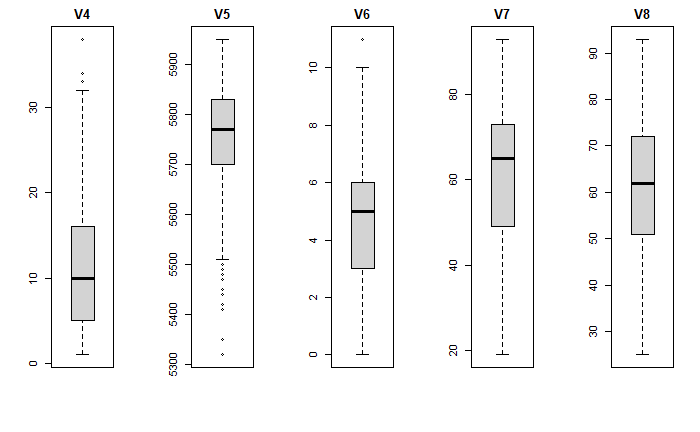

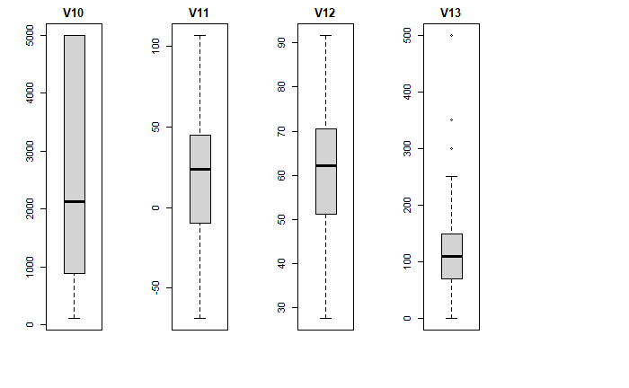

```r
#Boxplot de chaque variable
par(mfrow=c(1,5))
for(i in 3:11) {
boxplot(Ozone_bis[,i], main=names(Ozone_bis)[i])
}
```

Le principal inconvénient de l’arbre CART est le manque de stabilité. Le modèle est sensible aux variations (même assez faible). Il est donc important de distinguer les valeurs aberantes et de les supprimer. Sur les boxplot, on observe qu’on a des valeurs aberrantes pour les variables V4 (variable cible), V5, V6 et V13.

```r
Ozone_bis_2 <- Ozone_bis

#suppression valeur aberrante V4
outliersv4 <- boxplot(Ozone_bis_2$V4, plot=FALSE)$out
x4<-Ozone_bis_2
x4<- x4[-which(x4$V4 %in% outliersv4),]

#suppresion valeur aberrante V5
outliersV5 <- boxplot(Ozone_bis_2$V5, plot=FALSE)$out
x5<-x4
x5<- x5[-which(x5$V5 %in% outliersV5),]

#supression valeur aberrante V6
outliersV6 <- boxplot(Ozone_bis_2$V6, plot=FALSE)$out
x6<-x5
x6<- x6[-which(x6$V6 %in% outliersV6),]

#suppresion valeur aberrante V13
outliersV13 <- boxplot(Ozone_bis_2$V13, plot=FALSE)$out
Ozone_finale<-x6
Ozone_finale <- Ozone_finale[-which(Ozone_finale$V13 %in% outliersV13),]
Ozone_finale
```

|  | V1 | V3 | V4 | V5 | V6 | V7 | V8 | V10 | V11 | V12 | V13 |
| --- | --- | --- | --- | --- | --- | --- | --- | --- | --- | --- | --- |
| 3 | 1 | 6 | 3.000000 | 5710 | 4 | 28 | 40 | 2693 | -25 | 47.66 | 250 |
| 4 | 1 | 7 | 5.000000 | 5700 | 3 | 37 | 45 | 590 | -24 | 55.04 | 100 |
| 5 | 1 | 1 | 5.000000 | 5760 | 3 | 51 | 54 | 1450 | 25 | 57.02 | 60 |
| 6 | 1 | 2 | 6.000000 | 5720 | 4 | 69 | 35 | 1568 | 15 | 53.78 | 60 |
| 7 | 1 | 3 | 4.000000 | 5790 | 6 | 19 | 45 | 2631 | -33 | 54.14 | 100 |
| 8 | 1 | 4 | 4.000000 | 5790 | 3 | 25 | 55 | 554 | -28 | 64.76 | 250 |
| 9 | 1 | 5 | 6.000000 | 5700 | 3 | 73 | 41 | 2083 | 23 | 52.52 | 120 |
| 10 | 1 | 6 | 7.000000 | 5700 | 3 | 59 | 44 | 2654 | -2 | 48.38 | 120 |
| 11 | 1 | 7 | 4.000000 | 5770 | 8 | 27 | 54 | 5000 | -19 | 48.56 | 120 |
| 12 | 1 | 1 | 6.000000 | 5720 | 3 | 44 | 51 | 111 | 9 | 63.14 | 150 |

[output cut: 314 more lines]

```r
NA
```

[output not shown]

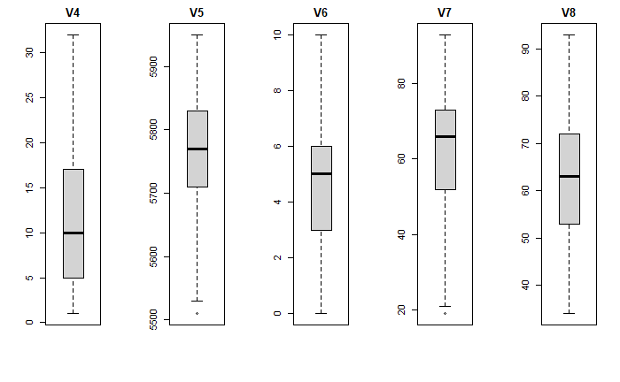

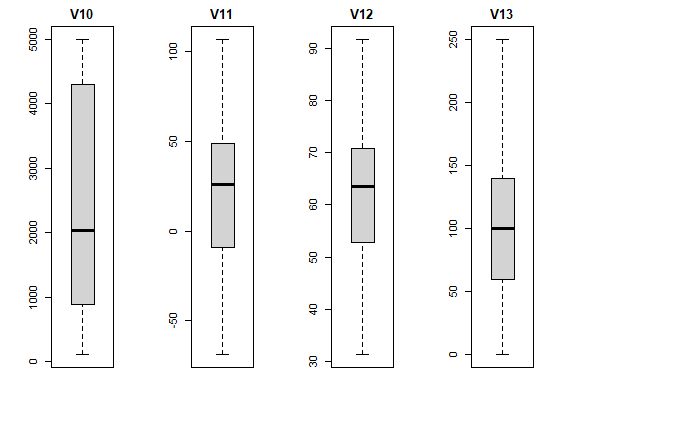

```r
#Boxplot de chaque variable
par(mfrow=c(1,5))
for(i in 3:11) {
boxplot(Ozone_finale[,i], main=names(Ozone_finale)[i])
}
```

# 3.3] Performances de modèle

On sépare les jeux de données avec 70% d’entrainement et 30% test.

```r
library(caTools)
set.seed(32)
split = sample.split(Ozone_finale$V4, SplitRatio = 0.7)
Ozone.app = subset(Ozone_finale, split == T)
Ozone.test = subset(Ozone_finale, split ==F)
```

```r
plot(density(Ozone.app$V4), type="l", col='blue')
lines(density(Ozone.test$V4), type="l", col='red')
```

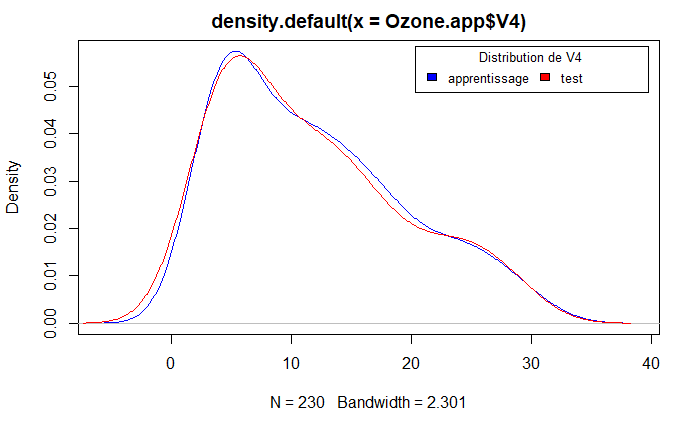

```r
legend("topright", inset=.02, title="Distribution de V4",
   c("apprentissage","test"), fill=c("blue","red"), horiz=TRUE, cex=0.8)
```

On se rend compte que la distribution de notre variable cible (V4) de l’entrainement et du test sont quasiment similaires.

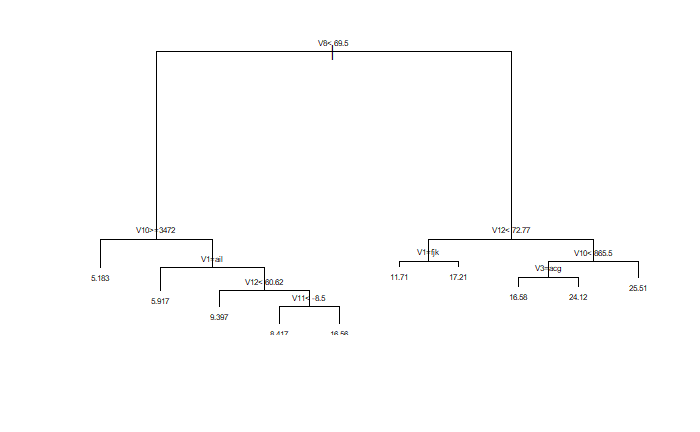

```r
library(rpart)
#Construction de l'arbre par defaut

z_def=rpart(V4 ~ .,data = Ozone.app)
plot(z_def)
text(z_def, cex = 0.5)
```

[output not shown]

On contruit maintenant l’arbre maximale

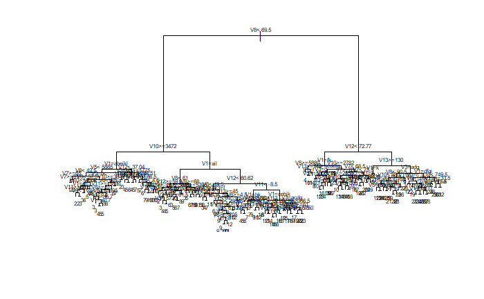

```r
#Construction de l'arbre maximale
{
tmaxOzone <- rpart(V4 ~ ., data = Ozone.app, control = rpart.control(minsplit = 2,cp = 0))
plot(tmaxOzone)
text(tmaxOzone, cex = 0.5)
}
```

```
-on a un rabre difficilemnt interprétable.
-V8 est la 1ère variable qui split au mieux les données comme l'arbre par défaut
```

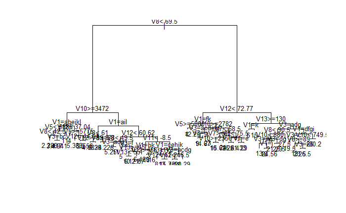

```r
#arbre optimal
zprune <- prune(tmaxOzone, cp = tmax$cptable[which.min(tmax$cptable[, 4]), 1])
plot(zprune)
text(zprune, cex = 0.8)
```

[output not shown]

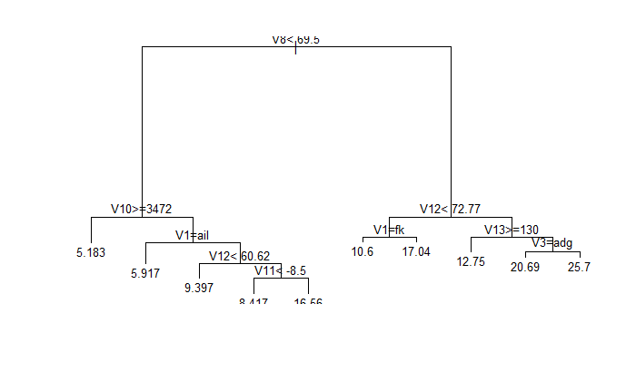

```r
#La régle du 1-SE
z_thres1SE <- sum(tmaxOzone$cptable[ which.min(tmaxOzone$cptable[, 4]), 4:5])
z_cp1SE <- tmaxOzone$cptable[ min(which(tmaxOzone$cptable[, 4] <= z_thres1SE)), 1]
zprune_1sd <- prune(tmaxOzone, cp = z_cp1SE)
plot(zprune_1sd)
text(zprune_1sd, cex = 0.8)
```

# 3.4] Comparaison des résultats

```r
library(Metrics)
#arbre par defaut
predz_def<-predict(z_def, Ozone.test)
errz_def <- sqrt(mse(Ozone.test$V4,predz_def))
appz_def = sqrt(mse(Ozone.app$V4,predict(z_def,Ozone.app)))
cat("\n \n  Pour l'arbre par defaut \n ")
```

```
  Pour l'arbre par defaut
```

```r
cat("Erreur test de l'arbre par defaut:",errz_def,"\n")
```

```
Erreur test de l'arbre par defaut: 4.537828
```

```r
cat("Erreur apprentissage de l'abre par defaut :",appz_def,"\n\n")
```

```
Erreur apprentissage de l'abre par defaut : 3.456946
```

```r
#arbre maximal
predmaxOzone<-predict(tmaxOzone, Ozone.test)
errmaxOzone <- sqrt(mse(Ozone.test$V4,predmaxOzone))
appmaxOzone = sqrt(mse(Ozone.app$V4,predict(tmaxOzone,Ozone.app)))
cat("\n \n  Pour l'arbre maximal \n ")
```

```
  Pour l'arbre maximal
```

```r
cat("Erreur de test est de:",errmaxOzone,"\n")
```

```
Erreur de test est de: 5.940113
```

```r
cat("Erreur d'apprentissage est de:",appmaxOzone,"\n\n")
```

```
Erreur d'apprentissage est de: 0
```

```r
#arbre optimal
predprune_oz<-predict(zprune, Ozone.test)
errpruneozone <- sqrt(mse(Ozone.test$V4,predprune_oz))
apppruneozone = sqrt(mse(Ozone.app$V4,predict(zprune,Ozone.app)))
cat("\n \n  Pour l'arbre optimal \n ")
```

```
  Pour l'arbre optimal
```

```r
cat("Erreur de test est de :",errpruneozone,"\n")
```

```
Erreur de test est de : 5.54913
```

```r
cat("Erreur d'apprentissage est de :",apppruneozone,"\n")
```

```
Erreur d'apprentissage est de : 1.363651
```

```r
#La régle du "1−SE"
predseOzone<-predict(zprune_1sd, Ozone.test)
errseOzone <- sqrt(mse(Ozone.test$V4,predseOzone))
appseOzone = sqrt(mse(Ozone.app$V4,predict(zprune_1sd,Ozone.app)))
cat("\n \n  la règle du 1 SE \n ")
```

```
  la règle du 1 SE
```

```r
cat("Erreur de test est de :",errseOzone,"\n")
```

```
Erreur de test est de : 5.049869
```

```r
cat("Erreur d'apprentissage est de :",appseOzone,"\n")
```

```
Erreur d'apprentissage est de : 3.434512
```

[output not shown]

```r
zprune_1sd$variable.importance
```

```
       V8       V12        V1        V5       V10       V11       V13        V7        V3
6953.2607 4432.8791 3887.4348 3703.5834 1701.5110 1297.9567  745.6396  401.3898  261.4025
```

```
-On observe que les 2 premieres variables les plus importantes sont liées la température (V8: Température mesuré à SandBurg,CA et V12 : Température de base de l'inversion à LAX ).

-On observe sur les arbres que le 1er split compétitif s'agit de la variable V8.
```

# 3.5] Bonus : interprétation sur l’importance des variables du modèle CART

Il peut être intéressant de s’intéresser en particulier à la variable V8 et d’observer pourquoi cette variable est si importante dans notre modèle. Pour cela je décide d’afficher le graphique de dépendance partielle qui a pour objectif de montrer l’effet marginal de cette variable explicative sur la prédiction faite par notre modèle. Ce graphique peut montrer si la relation entre la cible et une caractéristique est linéaire, monotone ou plus complexe.

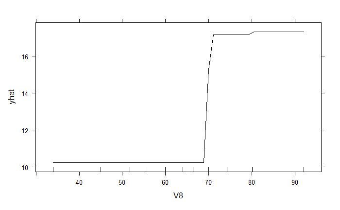

```r
library(pdp)
partial(zprune_1sd, pred.var = "V8",  plot = TRUE, rug = TRUE)
```

[output not shown]

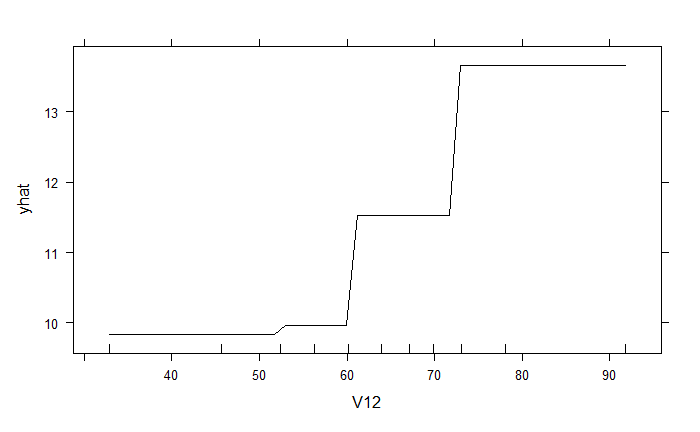

```r
partial(zprune_1sd, pred.var = "V12",  plot = TRUE, rug = TRUE)
```

```
On observe une courbe avec une croissance moins brusque que la variable V8. Cette variable a une influence sur la variable cible à plusieurs niveaux selon la valeur de l'inversion de la température de base (degrees F) à LAX. On observe des sauts assez brusque sur le graphique.
```

## 4] Les forêts aleatoires

On charge la lirairie random forest : Il s’agit d’une librairie de classification et régression basée sur une forêt d’arbres utilisant des entrées aléatoires, basée sur Breiman (2001)

## 4.1] Bagging

On applique la méthode du Bagging qui a été introduite par Breiman (1996)

```r
library(randomForest)
```

```r
## ----bag-----------------------------------------------------------------

bag <- randomForest(type ~ ., data = spam.app, mtry = p)
bag
```

```
Call:
 randomForest(formula = type ~ ., data = spam.app, mtry = p)
               Type of random forest: classification
                     Number of trees: 500
No. of variables tried at each split: 57

        OOB estimate of  error rate: 7.3%
Confusion matrix:
        nonspam spam class.error
nonspam    1325   69  0.04949785
spam         99  807  0.10927152
```

En sortie on a le classificateur, le nombre d’arbres (500), les variables à chaque division (57), une matrice de confusion et une estimation OOB du taux d’erreur.

[output not shown]

```r
predbag <- predict(bag, spam.test)
errbag <- round(sum(predbag != spam.test$type)/nrow(spam.test), 3) * 100
cat("L'erreur obtenu sur la base de test est de", errbag, "%")
```

```
L'erreur obtenu sur la base de test est de 6.8 %
```

```r
cat("\n l'erreur obtenu sur la base d'apprentissage est de", round(sum(predict(bag, spam.app) != spam.app$type)/nrow(spam.app), 3) * 100, "%")
```

```
 l'erreur obtenu sur la base d'apprentissage est de 0 %
```

[output not shown]

## 4.2] Random Forest par defaut

```r
rf <- randomForest(type ~ ., spam.app, importance = TRUE)
rf
```

```
Call:
 randomForest(formula = type ~ ., data = spam.app, importance = TRUE)
               Type of random forest: classification
                     Number of trees: 500
No. of variables tried at each split: 7

        OOB estimate of  error rate: 5.7%
Confusion matrix:
        nonspam spam class.error
nonspam    1346   48  0.03443329
spam         83  823  0.09161148
```

En sortie on a le classificateur, le nombre d’arbres (500), les variables à chaque division (7), une matrice de confusion et une estimation OOB du taux d’erreur.

[output not shown]

On va maintenant calculer l’erreur sur notre jeux de données test et apprentissage.

```r
## ----rf_err--------------------------------------------------------------

predrf <- predict(rf, spam.test)
predrf.app<- predict(rf, spam.app)
errrf.app <- round(sum(predrf.app != spam.app$type)/nrow(spam.app), 3) * 100
errrf <- round(sum(predrf != spam.test$type)/nrow(spam.test), 3) * 100
cat("Pour Random Forest par défaut ")
```

```
Pour Random Forest par défaut
```

```r
cat("\n L'erreur obtenue sur la base de test est de", errrf, "%")
```

```
 L'erreur obtenue sur la base de test est de 4.6 %
```

```r
cat("\n L'erreur obtenue sur la base d'apprentissage est de", errrf.app, "%")
```

```
 L'erreur obtenue sur la base d'apprentissage est de 0.4 %
```

```
On observe que pour les données test, le taux d'erreur de random forest par defaut (4.6%) est inférieur à celui du bagging (6.8%). Pour les données d'apprentissage, l'erreur de random forest (0.4%) est supérieur à celui du bagging (0%)

Jusqu'à maintenant random forest fait parti du modèle le plus performant.
```

On va maintenant étudier l’évolution de l’erreur OOB en fonction ntree en utilisant do.trace de random forest

```
ntree      OOB      1      2
  100:   5.83%  3.52%  9.38%
  200:   5.65%  3.30%  9.27%
  300:   5.83%  3.44%  9.49%
  400:   5.91%  3.44%  9.71%
  500:   5.83%  3.37%  9.60%
  600:   5.74%  3.30%  9.49%
  700:   5.78%  3.44%  9.38%
  800:   5.74%  3.52%  9.16%
  900:   5.91%  3.59%  9.49%
 1000:   5.87%  3.59%  9.38%
```

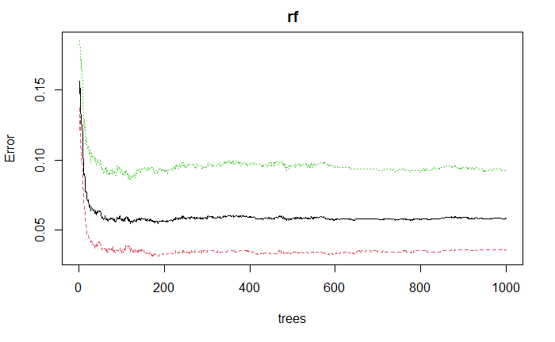

```r
{
rf <- randomForest(type ~ ., data = spam.app, ntree = 1000, do.trace = 100)
plot(rf)
}
```

On a sur le graphique : - En rouge l’erreur de la classe 1 (non spam) - En vert l’erreur de la classe 2 (spam) - En noir l’erreur OBB (taux de classification global)

Graphiquemennt, on observe que les erreurs ont tendance à se stabiliser. Pour gagner en temps de calcul il n’est pas nécessaire d’aller plus loin sur le nombre d’arbre qu’on doit construire. On peut par exemple s’arréter à partir de 500 feuille qui est la valeur par défaut pour le nombre d’arbre pour random forest ou 200 qui est le taux d’erreur OOB minimal d’après notre tableau.

# 4.3] Importance des variables

### 4.3.1] Random Forest par defaut

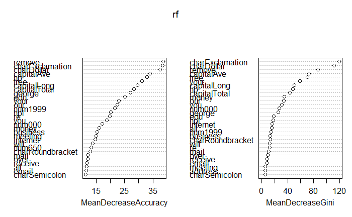

```r
rf <- randomForest(type ~ ., data = spam.app, importance = TRUE)
varImpPlot(rf)
```

[output not shown]

On affiche ci-dessous les top variables les plus importantes

```r
rfimp <- rf$importance[, nlev + 1]
rfimpsort <- sort(rfimp, decreasing = TRUE, index.return = TRUE)
cat("Les 8 variables les plus importantes sont : \n")
```

```
Les 8 variables les plus importantes sont :
```

```r
colnames(spam.app[rfimpsort$ix[1:8]])
```

```
[1] "remove"          "charExclamation" "capitalLong"     "hp"              "charDollar"      "capitalTotal"    "capitalAve"
[8] "free"
```

Remove est la variable la plus importante. Les variables les plus importants sont ceux qui ont un impact sur la valeur prédictive dans notre modèle.

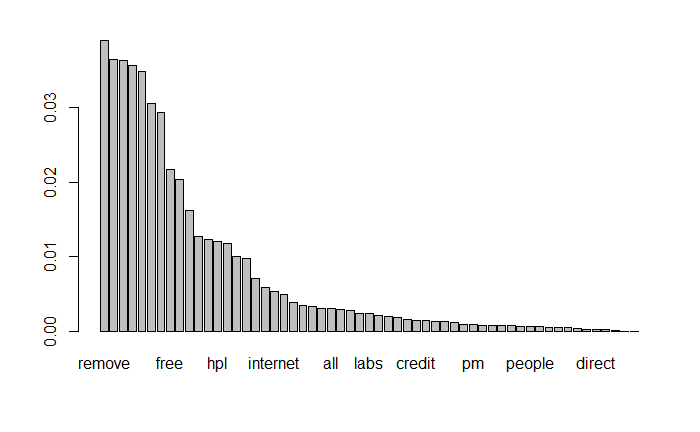

```r
nlev <- nlevels(spam.app$type)
barplot(sort(rf$importance[, nlev + 1], decreasing = TRUE, index.return = TRUE)$x)
```

Sur le grahique, en affichant l’ensemble des variables on observe qu’il y en a qu’il y a des variables comme num415 qui ont de trés faible importance pour le modèle, ses variables n”ont pas de gros impact sur la valeur prédictive comme remove, free … qui sont très importantes.

### 4.3.2] Random Forest de Stump

On se préocupe maintenant de random forest de stump

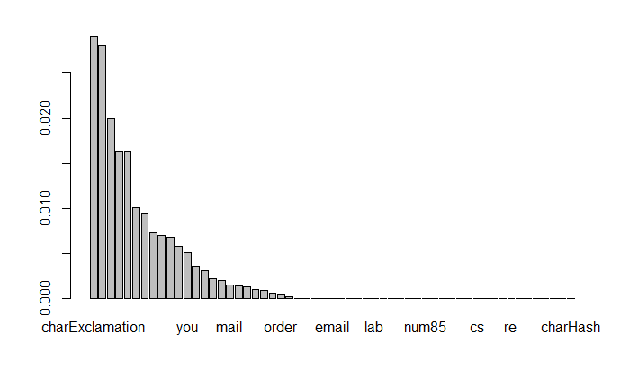

```r
rfstump <- randomForest(type~., spam.app, maxnodes=2, importance=TRUE)
rfstumpimpsort <- sort(rfstump$importance[, nlev+1], decreasing=TRUE,
index.return=TRUE)
barplot(rfstumpimpsort$x)
```

```r
rfimpstump <- rfstump$importance[, nlev + 1]
rfimpstumpsort <- sort(rfimpstump, decreasing = TRUE, index.return = TRUE)
cat("Les 8 variables les plus importantes sont : \n")
```

```
Les 8 variables les plus importantes sont :
```

```r
colnames(spam.app[rfimpstumpsort$ix[1:8]])
```

```
[1] "charExclamation" "charDollar"      "your"            "free"            "remove"          "money"           "capitalAve"
[8] "capitalTotal"
```

On ne retouve pas les mêmes importances de variable que le random forest par defaut. L’ordre de l’importance des variables n’est pas aussi la même. charExclamation est cette fois-ci la variable la plus importante.

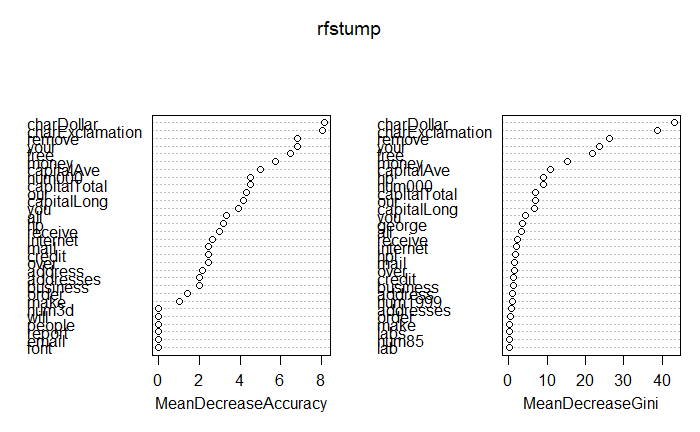

```r
varImpPlot(rfstump)
```

# 4.4] Illustration de l’influence du paramètre mtry sur l’erreur OOB ainsi que sur la VI

On peut améliorer la prédiction de Random Forest par rapport au paramètre mtry. mtry : le nombre de variables testées à chaque division

### 4.4.1] Pour mtry=p et maxnode 2

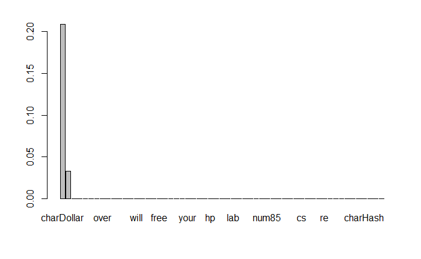

```r
bagstump <- randomForest(type~., spam.app, maxnodes=2, mtry=p, importance=TRUE)
bagstumpimpsort <- sort(bagstump$importance[, nlev+1], decreasing=TRUE,
index.return=TRUE)
barplot(bagstumpimpsort$x)
```

```r
colnames(spam.app[bagstumpimpsort$ix[1:8]])
```

```
[1] "charDollar"      "charExclamation" "make"            "address"         "all"             "num3d"           "our"
[8] "over"
```

```
En comparant avec le Random Forest de Stumps(mtry = p^(1/2)) et le bagging stump (mtry=p), on se rend compte qu'on a pas tout à fais les mêmes variables d'importance dans les modèles. Parmis les 8 variables, les seuls variables importantes qu'ils ont en commun sont : charDollar et charExclamation.
```

On compare l’erreur OOB des deux modèles en se basant avec celui qui contient tous les arbres.

```r
{
cat("On a une erreur d'OOB de", tail(bagstump$err.rate[, 1], 1) *100, "% pour le bagging stump (mtry=p) \n")
cat("On a une erreur d'OOB de", tail(rfstump$err.rate[, 1], 1)  *100, "% pour le Random Forest stump (mtry= p^(1/2))")
}
```

```
On a une erreur d'OOB de 20.6087 % pour le bagging stump (mtry=p)
On a une erreur d'OOB de 17.91304 % pour le Random Forest stump (mtry= p^(1/2))
```

On se rend compte que pour une valeur de mtry elevé (mtry=p), le taux d’erreur est plus important que la valeur par défaut. Il est donc préférable de ne pas tester le nombre maximum de variable à chaque division. On l’a traité avec un maxnodes=2. On a des taux d’erreurs assez elevée, il serait intéressant maintenant de traiter avec la valeur de maxnodes par défaut

### 4.4.2] Pour mtry = 1

```r
f1 <- randomForest(type~., spam.app, mtry=1, importance=TRUE)
tail(rf1$err.rate[, 1], 1)
```

[output not shown]

[figure not shown]

```r
rf1impsort <- sort(rf1$importance[, nlev+1], decreasing=TRUE, index.return=TRUE)
barplot(rf1impsort$x)
```

```r
colnames(spam.app[rf1impsort$ix[1:8]])
```

[output not shown]

```
En comparant avec les modèles précédentes on retrouve quelques variables en commun qui ressortent commun comme charExclamation, charDollar...
```

```r
{
cat("On a une erreur d'OOB de", tail(f1$err.rate[, 1], 1) *100, "% pour random forest avec 1 seule variable testé à chaque division (mtry=1) \n")
cat("On a une erreur d'OOB de", tail(bagstump$err.rate[, 1], 1) *100, "% pour le bagging stump (mtry=p) \n")
cat("On a une erreur d'OOB de", tail(rfstump$err.rate[, 1], 1)  *100, "% pour le Random Forest stump (mtry= p^(1/2))")
}
```

```
On a une erreur d'OOB de 8.652174 % pour random forest avec 1 seule variable testé à chaque division (mtry=1)
On a une erreur d'OOB de 20.6087 % pour le bagging stump (mtry=p)
On a une erreur d'OOB de 17.91304 % pour le Random Forest stump (mtry= p^(1/2))
```

Le taux d’erreur d’OOB est plus bas pour un mtry=1 et un maxnode par defaut, comparé aux deux autres modèles. Il serait intéressant d’augmenter la valeur de mtry en laissant le maxnode par defaut.

### 4.4.3] Pour mtry = p/3

```r
rfpsur3 <- randomForest(type~., spam.app, mtry=p/3, importance=TRUE)
```

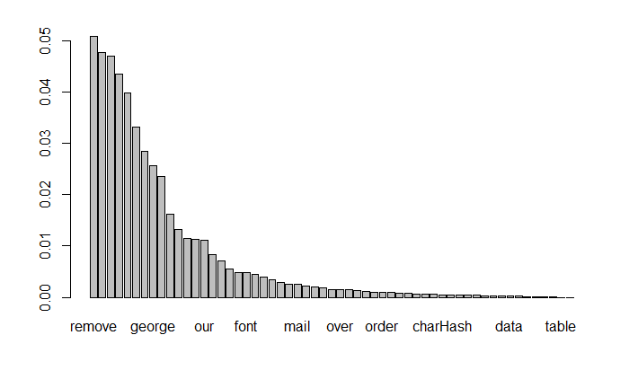

```r
rfpsur3impsort <- sort(rfpsur3$importance[, nlev+1], decreasing=TRUE,
index.return=TRUE)
barplot(rfpsur3impsort$x)
```

```r
colnames(spam.app[rfpsur3impsort$ix[1:8]])
```

```
[1] "remove"          "charExclamation" "charDollar"      "hp"              "capitalLong"     "capitalTotal"    "capitalAve"
[8] "george"
```

```r
{
cat("On a une erreur d'OOB de", tail(rfpsur3$err.rate[, 1], 1) *100, "% pour le Random Forest (mtry=p/3) \n")
cat("On a une erreur d'OOB de", tail(f1$err.rate[, 1], 1) *100, "% pour random forest avec 1 seule variable testé à chaque division (mtry=1) \n")
cat("On a une erreur d'OOB de", tail(bagstump$err.rate[, 1], 1) *100, "% pour le bagging stump (mtry=p) et maxnode=2 \n")
cat("On a une erreur d'OOB de", tail(rfstump$err.rate[, 1], 1)  *100, "% pour le Random Forest stump (mtry= p^(1/2)) et maxnode=2")
}
```

[output not shown]

Le taux d’erreur d’OOB a encore diminué avec un modèle mtry=P/3 et maxnodes par défaut.

### 4.4.4]mtry =p et maxnode par defaut

```r
rfp <- randomForest(type~., spam.app, mtry=p, importance=TRUE)
```

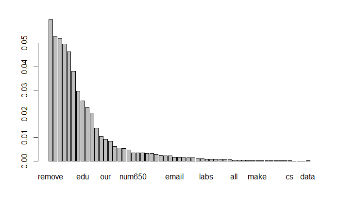

```r
{rfpimpsort <- sort(rfp$importance[,nlev+1], decreasing=TRUE, index.return=TRUE)
barplot(rfpimpsort$x)
}
```

```r
colnames(spam.app[rfpimpsort$ix[1:8]])
```

```
[1] "remove"          "hp"              "capitalLong"     "charDollar"      "charExclamation" "george"          "capitalTotal"
[8] "edu"
```

```r
{
cat("On a une erreur d'OOB de", tail(rfp$err.rate[, 1], 1) *100, "% pour le Random Forest (mtry=p) \n")
cat("On a une erreur d'OOB de", tail(rfpsur3$err.rate[, 1], 1) *100, "% pour le Random Forest (mtry=p/3) \n")
cat("On a une erreur d'OOB de", tail(f1$err.rate[, 1], 1) *100, "% pour random forest avec 1 seule variable testé à chaque division (mtry=1) \n")
cat("On a une erreur d'OOB de", tail(bagstump$err.rate[, 1], 1) *100, "% pour le bagging stump (mtry=p) et maxnode=2 \n")
cat("On a une erreur d'OOB de", tail(rfstump$err.rate[, 1], 1)  *100, "% pour le Random Forest stump (mtry= p^(1/2)) et maxnode=2")
}
```

[output not shown]

On obtient cette fois-ci une erreur un peu plus elevé pour mtry=p.

Ce qu’on peut en conclure d’après nos résultats:

```
-On ne doit pas limiter la profondeur de nos arbres à 1 car on aura des taux d'erreurs elevées. Dans ce cas il serait préferable de mettre la valeur de mtry à 1
-En laissant la profondeur de l'arbre par défaut, on ne doit pas choisir une valeur de mtry trop basse, ni trop elevée. Dans notre cas, on a vu que ptry=p/3 nous donnait le taux d'erreur la moins elevé.
```

On a remarqué que les importances de variables ne sont pas les mêmes, on ne peut pas dire qu’un modèle est meilleur selon ses performances.

## 4.5] Boite à moustache

On va constuire un modèle avec 100 arbres et un autre avec 500 arbres (nombres par défaut) pour étudier l’importance des variables.

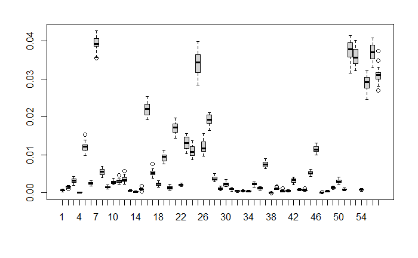

```r
#On fait 20 simulation
vimultntree100 <- matrix(NA, nrow = 20, ncol = p)
for (i in 1:20) {
rf <- randomForest(type ~ ., spam.app, ntree = 100, importance = TRUE)
vimultntree100[i, ] <- rf$importance[, nlev + 1]
}
boxplot(vimultntree100)
```

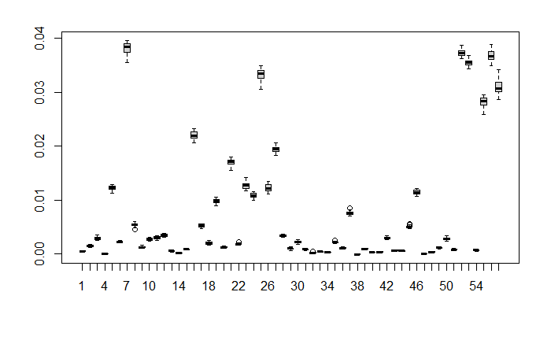

```r
#on fait 20 simulations
vimult <- matrix(NA, nrow = 20, ncol = p)
for (i in 1:20) {
rf <- randomForest(type ~ ., spam.app, importance = TRUE)
vimult[i, ] <- rf$importance[, nlev + 1]
}
boxplot(vimult)
```

```
On observant Les boxplots des modèles, on remarque que la variance est plus elevée pour le modèle à 100 arbres comparé à 500 arbres. On a un modèle plus robuste avec 500 arbres.

On peut s'en rendre compte que les variables les plus importantes sont ceux qui sont eloigné de l'axe des abscisse , on peut retrouver les variables comme charExclamation, charDollar, capitalLong, capitalTotal...
```

# 5] Vsurf

##5.1] Application de Vsurf

On charge la librarie VSURF qui est un package R pour la sélection de variables à l’aide de forêts aléatoires.

```r
library(VSURF)
```

On appliquer VSURF sur un sous-ensemble de 500 observations du tableau de données spam.app pour un temps de calcul plus rapide.

```r
small.n <- 500
ytable.app <- table(spam.app$type)
small.app <- c(sample(1:ytable.app[2], ytable.app[2]/n * small.n),
sample((ytable.app[2] + 1):n, ytable.app[1]/n * small.n))
spam.small.app <- spam.app[small.app, ]
table(spam.small.app$type)
```

```
nonspam    spam
    303     196
```

```r
vsurf.stump <- VSURF(type ~ ., spam.small.app, maxnodes = 2)
```

```
Thresholding step
Estimated computational time (on one core): 46 sec.

Interpretation step (on 19 variables)
Estimated computational time (on one core): between 4.8 sec. and  33.2 sec.

Prediction step (on 6 variables)
Maximum estimated computational time (on one core): 4.5 sec.
```

## 5.2 Interprétation grpahiques

```r
summary(vsurf.stump)
```

```
 VSURF computation time: 1.1 mins

 VSURF selected:
    19 variables at thresholding step (in 39.2 secs)
    6 variables at interpretation step (in 22 secs)
    3 variables at prediction step (in 4.1 secs)
```

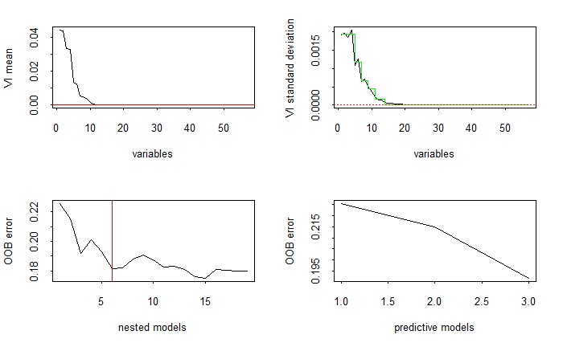

```r
plot(vsurf.stump)
```

```r
colnames(spam.app[vsurf.stump$varselect.interp])
```

```
[1] "charDollar"      "charExclamation" "remove"          "capitalAve"      "free"            "your"
```

Dans les sorties du “summary”, nous avons des étapes pour la selection de variable :

1] Le classement des variables selon leurs importances par ordre décroissante.

-1] Un seuil est définit. Les variables sont filtées selon le seuil. On retient toutes les variables supérieurs à ce seuil et on rejete le reste. Ce seuil est choisit automatiquement par l’algorithme.

-2] Les variables sont choisit selon leurs intérprétations

-3] Les variables qui sont finalement gardé sont ceux qui sont pertinentes pour la prédiction.

### 5.2.1] figure 1 (en haut à gauche)

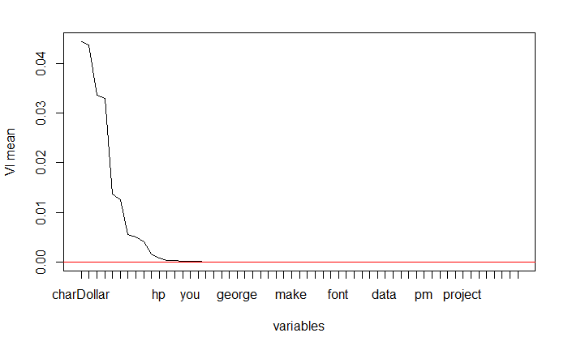

```r
plot(vsurf.stump, step = "thres", imp.sd = FALSE, var.names = TRUE)
```

[output not shown]

### 5.2.2] figure 2 (en haut à droite)

[output not shown]

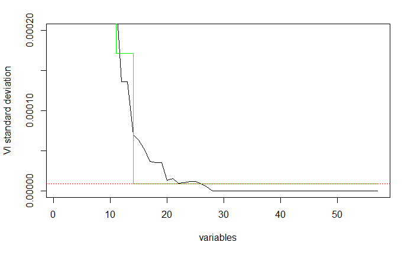

```r
#Zoom sur le graphique en haut à droite
plot(vsurf.stump, step = "thres", imp.mean = FALSE, ylim = c(0, 2e-4))
```

```
En faisant un zoom, nous pouvons voir dans le graphique que les écarts types des vraies variables sélectionnées sont plus dispersées par rapport à ceux des variables rejetés qui sont proches de zéro. Les écart-types sont de plus en plus petit. Le seuil retenu conduit à conserver 19 variables
```

### 5.2.3] Figure 3 (en bas à gauche)

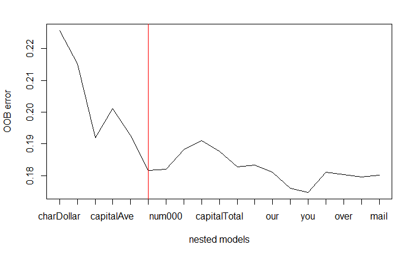

```r
plot(vsurf.stump, step = "interp", imp.sd = FALSE, var.names = TRUE)
```

[output not shown]

### 5.2.4]figure 4 (en bas à droite)

[output not shown]

```r
spam.vsurf.pred <- VSURF_pred(type ~ ., spam.small.app, err.interp = spam.interp$err.interp, varselect.interp = spam.interp$varselect.interp)
```

[output not shown]

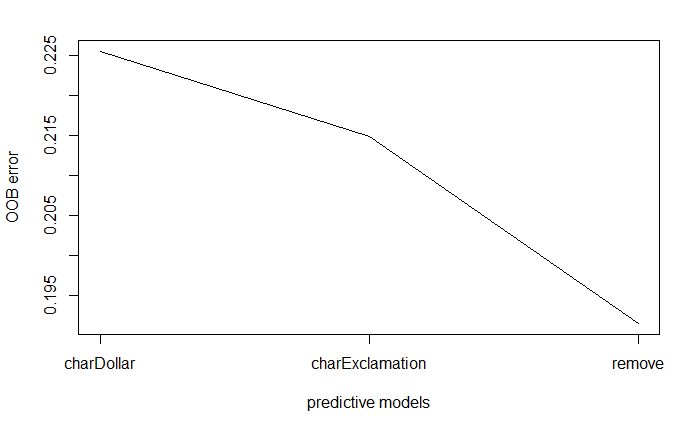

```r
{
plot(vsurf.stump, step = "pred", imp.sd = FALSE, var.names = TRUE)
}
```

```r
NA
```

On observe que l’erreur OOB diminue. Une variable est introduite seulement si la réduction de l’erreur est plus grande qu’un seuil : la réduction de l’erreur doit être significativement plus grande que la variabilité moyenne obtenue en ajoutant des variables de bruit. Au final, on a 3 variables qui on été gardé par le modèle, parmis les variables qui sont gardés on a : charDollar, charExclamation, remove.

# 5.2.5]Bonus VSURF en parallele

On détermine donc le nombre de cœurs utilisés pour exécuter VSURF en parallèle (NULL si VSURF n’a pas fonctionner en parallèle)

```r
vsurf.spam <- VSURF(type~., spam.app, parallel = TRUE, ncores = 6)
```

```
Thresholding step
Estimated computational time (on one core): 1790.5 sec.

Interpretation step (on 55 variables)
Estimated computational time (on one core): between 357.5 sec. and  5816.2 sec.

Prediction step (on 21 variables)
Maximum estimated computational time (on one core): 1008 sec.
```

```r
summary(vsurf.spam)
```

```
 VSURF computation time: 33.4 mins

 VSURF selected:
    55 variables at thresholding step (in 9.8 mins)
    21 variables at interpretation step (in 15.1 mins)
    15 variables at prediction step (in 8.5 mins)

 VSURF ran in parallel on a PSOCK cluster and used 6 cores
```

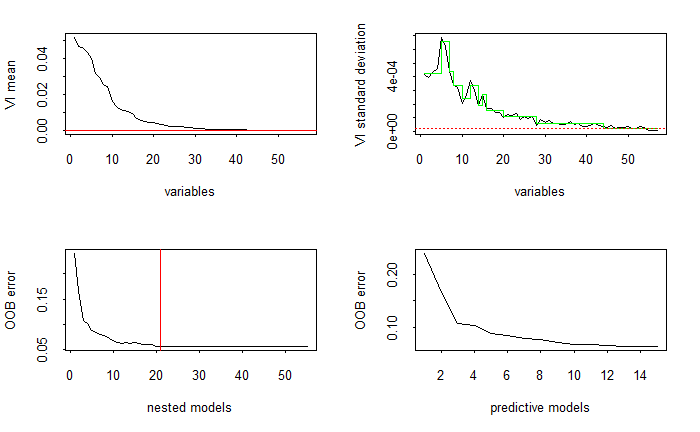

```r
plot(vsurf.spam)
```

```r
colnames(spam.app[vsurf.spam$varselect.interp])
```

```
 [1] "remove"          "charExclamation" "charDollar"      "hp"              "capitalLong"     "capitalTotal"    "capitalAve"
 [8] "george"          "free"            "edu"             "your"            "num000"          "hpl"             "our"
[15] "money"           "num1999"         "you"             "business"        "font"            "re"              "num650"
```

[output not shown]

# Conclusion

Les arbres CART pour la régression et la classification peuvent être construites de plusieurs façons (avec les paramètres par défaut, arbre stump, arbre maximal, arbre optimal, arbre avec l’application de la règle 1-SE de Bieinman…). L’arbre optimal (prune) ou la règle du 1-SE, nous donne de meilleures performances sur de nouveaux jeux de données. Les performances restent correctes mais peuvent être améliorées. L’inconvénient du CART est le manque de stabilité de l’algorithme, pour corriger cela on peut faire appel à d’autres méthodes comme Random Forests et le bagging. En utilisant ses algorithmes d’ensemble, on a cet avantage que les performances seront meilleurs que CART mais on a un “effet de boîte de noire”. En effet, le modèle n’est pas facile à interpréter et on peut faire appel à des méthodes d’interprétabilité comme le PDP (Partial Dependence Plot) ou sélectionner toutes les variables importantes, même si elles sont rebondantes, dans un but d’interprétation. Pour VSRUF, lorsqu’on a moins d’observation (n) et beaucoup de variables(p) (n< p), il est préférable d’utiliser cette technique pour ne garder que les variables qui sont significatives. Grâce à cette méthode, on trouve un ensemble parcimonieux de variables importantes suffisant pour la prédiction.